# Women’s Work: COVID Impact on Female Employment

Isha Tanwar

2025-06-16

```r
library(readxl)
library(dplyr)
```

```r
library(ggplot2)
library(tidyr)
library(ggalt)
national<- read_excel("r_practice.xlsx", sheet = "national")
urban <- read_excel("r_practice.xlsx", sheet = "urban")
rural <- read_excel("r_practice.xlsx", sheet = "rural")
```

## National Employment Indicators by Gender

This report analyzes the impact of COVID-19 on women’s employment in India using PLFS data (2017–18 to 2020–21).  
We focus on trends in Labour Force Participation Rate (LFPR), Worker Population Ratio (WPR), and Unemployment Rate (UR) — especially for women in urban and rural areas.

Our goal: **Tell a data story using R and ggplot2.**

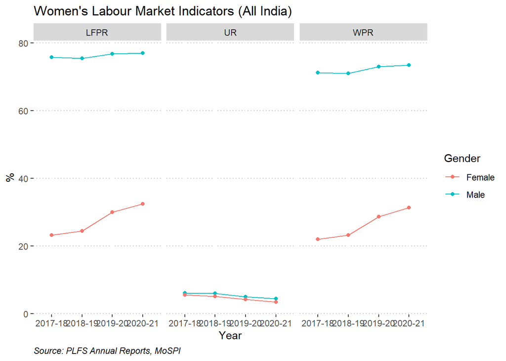

```r
national_long <- national %>%
  pivot_longer(cols = c(LFPR,WPR,UR), names_to = "Indicator", values_to = "Value")

national_long_line <- national_long %>% ggplot(aes(Year, Value, group = Gender)) +
  geom_line(aes(colour = Gender)) +
  geom_point(aes(colour = Gender)) +
  labs(title = "Women's Labour Market Indicators (All India)",
       y = "%", caption = "Source: PLFS Annual Reports, MoSPI") +
  theme(panel.background = element_blank(),
        panel.grid.major.y = element_line(colour = "grey", linetype = "dotted"),
        plot.caption = element_text(hjust = 0, face = "italic")) +
  facet_wrap(~ Indicator)
national_long_line
```

## Urban vs Rural WPR Comparison (2018-19 vs 2020-21)

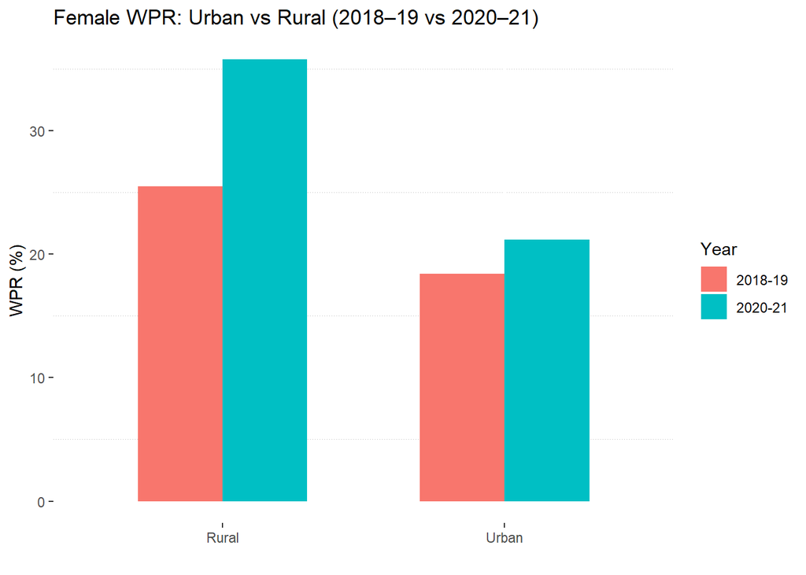

```r
combined_wr <- bind_rows(
  mutate(urban, Area = "Urban"),
  mutate(rural, Area = "Rural"))
df2020 <- combined_wr %>% filter(Year %in% c("2018-19","2020-21"), Gender == "Female")
wpr_bar <- ggplot(df2020, aes(x = Area, y = WPR, fill = Year)) +
  geom_bar(stat = "identity", position = "dodge", width = 0.6) +
  labs(title = "Female WPR: Urban vs Rural (2018–19 vs 2020–21)",x = "",y = "WPR (%)",
       fill = "Year") +
  theme(panel.background = element_blank(),
        panel.grid.minor.y = element_line(colour = "grey", linetype = "dotted"))
wpr_bar
```

[figure not shown]

```r
df_dumbbell <- urban %>%
  filter(Gender == "Female", Year %in% c("2017-18", "2020-21")) %>%
  select(Year, WPR)
df_dumbbell <- tibble(
  Area = "Urban",
  `2017-18` = df_dumbbell$WPR[1],
  `2020-21` = df_dumbbell$WPR[2])
df_dumbbell_line <- ggplot(df_dumbbell, aes(y = Area, x = `2017-18`, xend = `2020-21`)) +
  geom_dumbbell(color = "grey", size = 1.5,
                colour_x = "blue", colour_xend = "red") +
  labs(title = "Drop in Urban Female WPR: Before vs After COVID",x = "WPR (%)",y = "") +
  theme_minimal()
df_dumbbell_line
```

## Conclusion

The graphical analysis of female labour market participation in India highlights key patterns and post-pandemic shifts:

### Overall Labour Indicators by Gender (All India):

Female Labour Force Participation Rate (LFPR) and WPR show a gradual rise from 2017–18 to 2020–21, while the Unemployment Rate (UR) has marginally declined.

This trend hints at slow but positive gains in female engagement with the labour market, albeit from a low base.

### Urban vs Rural Comparison (2018–19 & 2020–21):

Rural females had consistently higher WPR than urban females in both years.

The increase in rural female WPR was sharper, suggesting a COVID-driven rural employment push, possibly in agriculture or informal sectors.

Urban female WPR remained low, reflecting challenges in re-entering the urban formal labour market after the pandemic.

A focused look at urban women’s WPR before and after COVID-19 shows a modest improvement post-pandemic, but it still lags behind rural trends.

This reflects that while some recovery has happened, urban structural issues like job losses in services, mobility constraints, and caregiving responsibilities continue to restrict women’s return to work.